# Midterm

Kris Walker

10/16/2019

# The School Bookstore

## Import and and Manipulate the register.csv Data

First we load the necessary libraries.

```r
library(tidyverse)
library(forcats)
```

Then we import the register.csv data itself.

```r
register_data <- read_csv("register.csv", na = "--")
```

We notice that some of the column names are clunky and/or wordy, so the first thing we’ll do is change the column names.

```r
colnames(register_data) <- c("purchase", "item", "charge", "price", "customer_type", "customer_id", "receipt", "contact_preferences",
                             "newsletter", "sales", "preferred_customer_discount")
```

The data exhibits an observation scattered across two rows. Simply uisng spread() didn’t work for some indexing issue.

```r
register_data <- register_data %>%
  group_by_at(vars(- price)) %>%           #Group by everything other than the value column.
  mutate(row_id = 1:n()) %>%
  ungroup() %>%                            #Build group index.
  spread(key = charge, value = price) %>%  #spread
  select(- row_id)                         #Drop the index
```

The `customer_type` variable has 0’s for university affiliated customers and 1’s for unaffiliated customers. We can change this to False and True, respectively.

```r
register_data$customer_type <- as.logical(as.integer(register_data$customer_type))
```

We can convert the variable `contact_preferences` to a factor variable.

```r
register_data$contact_preferences <- as_factor(register_data$contact_preferences)
```

Coerce the variable `item` from a double to a character since it’s not a mathematical number, its for i.d. only. We’ll go ahead and convert it to a factor as well for any possible future analysis, just in case.

```r
register_data$item <- as.character(register_data$item)
register_data$item <- as.factor(register_data$item)
```

Convert the dataframe `register_data` into a tibble.

```r
register_data <- as_tibble(register_data)
```

Let’s take a look at the first few rows of it to confirm its appearance.

```r
head(register_data, 5)
```

```
## # A tibble: 5 x 11
##   purchase item  customer_type customer_id receipt contact_prefere…
##      <dbl> <fct> <lgl>               <dbl> <lgl>   <fct>
## 1        1 3969… FALSE                   4 FALSE   email
## 2        2 3969… TRUE                   NA TRUE    <NA>
## 3        2 5198… TRUE                   NA TRUE    <NA>
## 4        2 5280… TRUE                   NA TRUE    <NA>
## 5        3 2028  FALSE                   4 TRUE    email
## # … with 5 more variables: newsletter <lgl>, sales <lgl>,
## #   preferred_customer_discount <lgl>, cost <dbl>, tax <dbl>
```

## Import and Manipulate the sales.csv Data

Go ahead and import `sales.csv`.

```r
sales_data <- read.csv("sales.csv")
```

One variable `category.of.inventory.goods` is spread across multiple columns.

```r
sales_data <- sales_data %>%
  gather(X1.2018:X10.2019, key = "year", value = "monthly_amount")
```

Separate the month from the year under the `year` variable.

```r
sales_data <- sales_data %>%
  separate(year, into = c("month", "year"))
```

Rename the values of the variable month so that they’re easier to intuit.

```r
sales_data$month[sales_data$month == "X1"] <- "January"
sales_data$month[sales_data$month == "X2"] <- "February"
sales_data$month[sales_data$month == "X3"] <- "March"
sales_data$month[sales_data$month == "X4"] <- "April"
sales_data$month[sales_data$month == "X5"] <- "May"
sales_data$month[sales_data$month == "X6"] <- "June"
sales_data$month[sales_data$month == "X7"] <- "July"
sales_data$month[sales_data$month == "X8"] <- "August"
sales_data$month[sales_data$month == "X9"] <- "September"
sales_data$month[sales_data$month == "X10"] <- "October"
sales_data$month[sales_data$month == "X11"] <- "November"
sales_data$month[sales_data$month == "X12"] <- "December"
```

Separate the inventory categories in sales_data so we may see how much each item type made per month.

```r
sales_data <- sales_data %>%
  group_by_at(vars(- monthly_amount)) %>%           #Group by everything other than the value column.
  mutate(row_id = 1:n()) %>%
  ungroup() %>%                            #Build group index.
  spread(key = category.of.inventory.goods, value = monthly_amount, convert = TRUE) %>%  #spread
  select(- row_id)                         #Drop the index
```

Lets take a look at how `sales_data` looks now.

```r
head(sales_data, 5)
```

```
## # A tibble: 5 x 10
##   month year  accessories apparel drinks electronics  food `health, beauty…
##   <chr> <chr>       <int>   <int>  <int>       <int> <dbl>            <int>
## 1 April 2018            6      10     19          11 16.6                 0
## 2 April 2019           18      10     19          16 16                   3
## 3 Augu… 2018           10       9     10          59  5                   1
## 4 Augu… 2019           17       2      9          62  3.14                2
## 5 Dece… 2018           13      16      4          20  6.4                 1
## # … with 2 more variables: supplies <int>, textbooks <int>
```

## Looking For Insights

Get the total purchase amount from each unique purchase (including tax).

```r
total_individual_purchases <- rep.int(0, times = 20)
for  (i in 1:length(unique(register_data$purchase))){
  total_individual_purchases[i] <- sum(register_data$cost[register_data$purchase == i] + register_data$tax[register_data$purchase == i])
}
```

This allows us to see that there were 20 recorded purchases. The minimum purchase made was .70 and the maximum was about $2130 dollars. The mean purchase was about $144 dollars.

```r
summary(total_individual_purchases)
```

```
##    Min. 1st Qu.  Median    Mean 3rd Qu.    Max.
##    0.70    6.05   24.27  144.81   81.89 2130.80
```

Make a tibble with sales data.

```r
register_sales <- tibble(
  item = register_data$item,
  cost = register_data$cost,
  tax = register_data$tax
)
```

How many times were each of the items purchased?

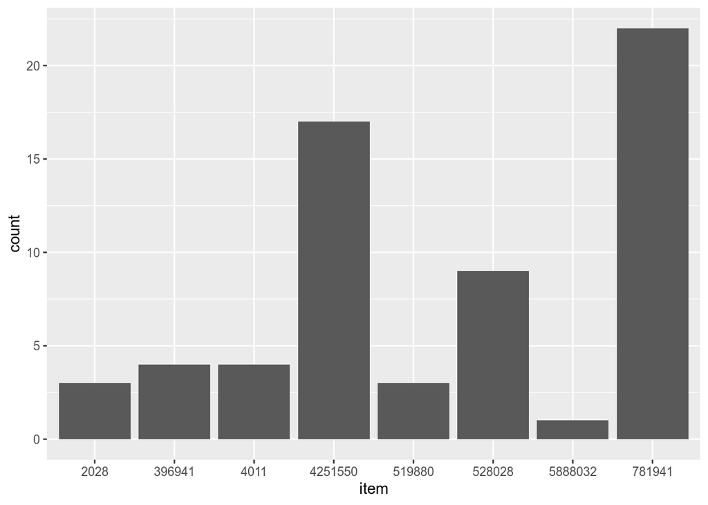

```r
ggplot(register_data, aes(item)) +
  geom_bar()
```

```r
register_data %>%
  count(item)
```

```
## # A tibble: 8 x 2
##   item        n
##   <fct>   <int>
## 1 2028        3
## 2 396941      4
## 3 4011        4
## 4 4251550    17
## 5 519880      3
## 6 528028      9
## 7 5888032     1
## 8 781941     22
```

It appears as thought the top two most frequent items purchased are items 781941 followed by 4251550. Item 5888032 is purchased the least frequently.

```r
summary(sales_data)
```

```
##     month               year            accessories       apparel
##  Length:22          Length:22          Min.   : 2.00   Min.   : 2.00
##  Class :character   Class :character   1st Qu.: 6.25   1st Qu.: 6.25
##  Mode  :character   Mode  :character   Median :10.50   Median : 9.50
##                                        Mean   :10.82   Mean   :10.27
##                                        3rd Qu.:14.75   3rd Qu.:15.75
##                                        Max.   :20.00   Max.   :20.00
##      drinks       electronics         food
##  Min.   : 4.00   Min.   : 2.00   Min.   : 2.800
##  1st Qu.: 8.00   1st Qu.: 6.50   1st Qu.: 5.375
##  Median : 9.50   Median :13.50   Median : 9.775
##  Mean   :11.45   Mean   :16.18   Mean   : 9.464
##  3rd Qu.:12.00   3rd Qu.:18.75   3rd Qu.:12.675
##  Max.   :25.00   Max.   :62.00   Max.   :16.600
##  health, beauty, and fitness    supplies       textbooks
##  Min.   :0.000               Min.   : 2.00   Min.   :  3.00
##  1st Qu.:1.000               1st Qu.: 8.00   1st Qu.: 10.00
##  Median :2.000               Median :10.00   Median : 17.50
##  Mean   :1.636               Mean   :10.77   Mean   : 60.41
##  3rd Qu.:2.750               3rd Qu.:14.50   3rd Qu.:103.75
##  Max.   :3.000               Max.   :20.00   Max.   :250.00
```

Here our five number summary provides some useful information about each category of item. Textbooks and electronics produce the maximum sales, while the health beauty and fitness category’s contribution is nominal.

Whats our customer type distribution look like?

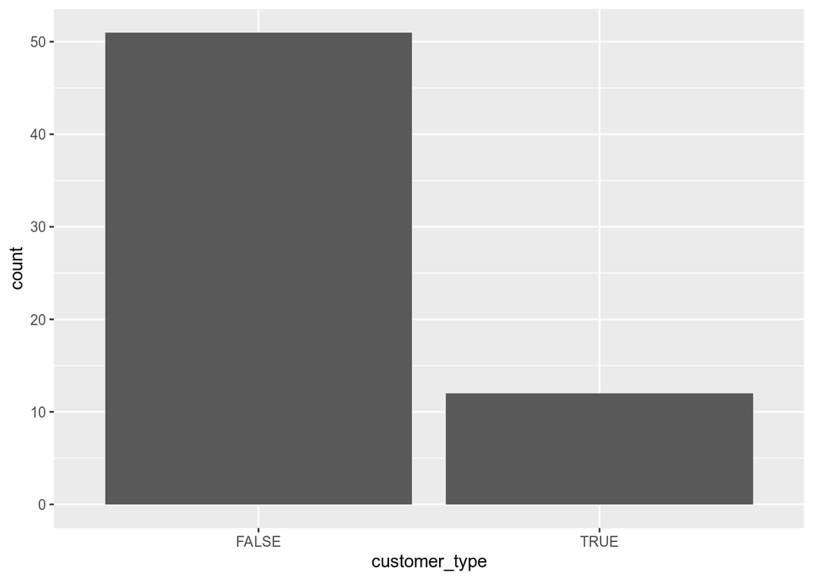

```r
ggplot(register_data, aes(customer_type)) +
  geom_bar()
```

```r
register_data %>%
  count(customer_type)
```

```
## # A tibble: 2 x 2
##   customer_type     n
##   <lgl>         <int>
## 1 FALSE            51
## 2 TRUE             12
```

Alomost 20 percent of our customers are unaffiliated with the university. Parents and family members make up a significant portion of our market.

What items are our two types of customers purchasing according to our register data?

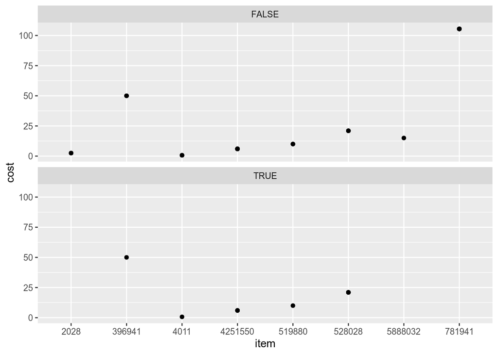

```r
ggplot(data = register_data) +
  geom_point(mapping = aes(x = item, y = cost)) +
  facet_wrap(~customer_type, nrow = 2)
```

Students are buying item 781941 while non students aren’t; this may be corroborating evidence that textbooks are the top moneymaker in the store. The Students and unaffiliated customers alike are both buying 396941. Could that item be apparel?